# Statistical Power and Mixed Effect Models

Timothée Bonnet  
June 1st 2018

### What is power?

[figure not shown]

Probability to detect an effect **that exists for real**

= 1 - false negative rate (type II error)

### Why should you think about statistical power?

**Low power means:**

- **Statistical tests non-significant whether an effect exists or not**
- **Your results will be inconclusive**
- **Data collection and analyses are wasted** (*maybe not completely, there is a twist later on*)

**High power means:**

- **Test probably significant when an effect exists**
- **Test rarely significant when an effect does not exist**
- **You learn something about the world**

### Think about power early and late

**BEFORE planning experiment or data collection:**

- Can I get enough data to answer my question? Is it worth it?
- How to improve my chances of detecting an effect **if it exists**?

But also AFTER doing an analysis:

- Is this non-significant result due to a lack of power or to the absence of an effect?
- What is the maximal likely value of the effect? Is it still important biologically?

### What power depends on

**1. Sample size**

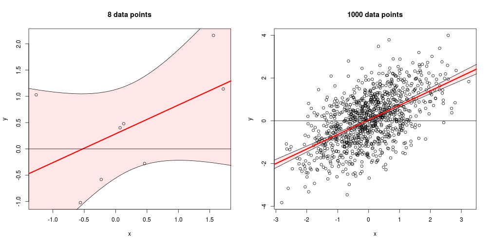

### What power depends on

**2. Strength of the effect**

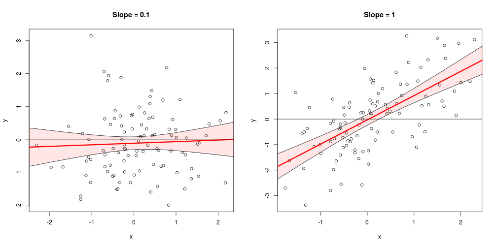

### What power depends on

**3. Unexplained variation**

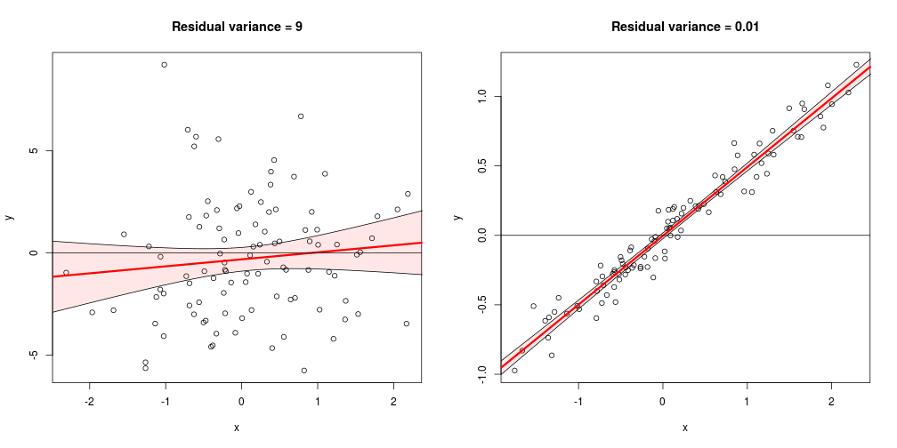

### Statistical power increases with

- **Larger sample size** <- you can control
- **Smaller unexplained variability** <- you can sometimes control
- **Real strength of the effect of interest** <- you cannot control

### We can estimate statistical power

If we know or assume:

- A sample size
- Explained and unexplained sources of variation
- A real strength of the effect

**Computer simulations**

### Exercise 1: power calculated by sample size

See file tempPA

We assume we know the data variability. How many samples to find a difference of 0.5?

### Simple solution for simple cases: pwr package

```r
library(pwr)
p40 <- pwr.t.test(n = 40, d = 0.5/1 )
p40$power
```

```
[1] 0.5981469
```

```r
p143 <- pwr.t.test(n = 143, d = 0.5/1 )
p143$power
```

```
[1] 0.9878887
```

### Exercise 2: power calculated by sample size and effect size

Try several values between zero and one for the assumed effect size in the simulations (pwr is allowed)

Show how power varies with sample size and effect size

You did the experiment with a sample size 100 and did not find a significant result. Let's assume a value less than 0.7 is biologically unimportant. Can you conclude something?

What if a value of 0.1 is still biologically important?

**Post-hoc power analysis**

## Mind the structure of unknown variation!

### What is really the sample size?

We have assumed observations to be **independent** in our simulations

Corresponds to an assumption of linear models

What if they are not?

### A silly example

Does size differ between French people and Brazilian people?

Very few individuals available here => we take 50 measurements of each person

*t-test of the difference, p<0.0001…*

**In reality, the data contain no information because the measurements are perfectly dependent: Effective sample size is 2, question has 2 parameters. Power=0**

### More realistic examples

Two bird populations, one supplemented with food. Measure reproductive success within populations, test the effect of food on reproduction. Effective sample size?

**2, for 2 parameters => no information, no power**

300 mass measurements of 50 individuals. Does mass impact on lifetime reproductive success? Effective sample size?

**50, for 2 parameters => some information / power**

### More realistic examples

?

- Inference about individuals with multiple measurements of same individuals
- Inference about spatial variation with several measurements per site
- Inference about trait co-evolution within a phylogeny
- …

### Solution: model the correlation between observations

- With fixed effects for grouping factors
- or **With a random effect in a mixed model**

**package lme4**

### Exercise

- Load RepeatedMeasurements.csv (10 measurements per individual) and IndividualMeasurements.csv (1 measurement per individual)
- Do the two groups differ in “value”? (use lm() and lmer() to test the difference)

### Exercise again!

The previous data were generated by the code contained in CodeForOneSimulation1.R

Modify it to estimate the false positive rate (when diffgroup = 0), and the power (when diffgroup = 0.5) for lm() and lmer(), with non-duplicated and with duplicated data

(NB: probably need of for loop, and look at the distribution of t-values instead of p-values)

What model is more powerful? Which one should you use?

### BONUS: Non-independance can also hide or reverse an effect

### Example: thorns and herbivory

Does a defensive tissue (thorns) reduce herbivory on a plant species?

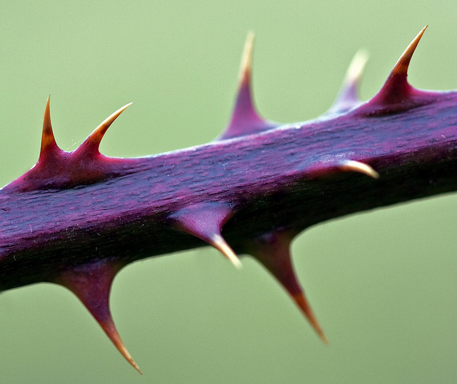

Collected data in 5 locations to reach large sample size

### Example: thorns and herbivory

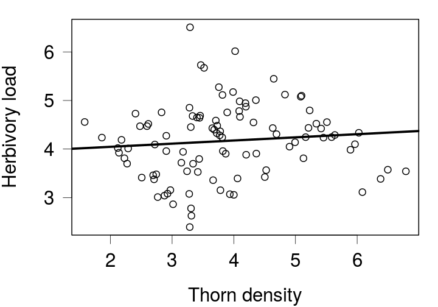

### Example: thorns and herbivory

```r
summary(lm(y~ x))
```

```
Call:
lm(formula = y ~ x)

Residuals:
     Min       1Q   Median       3Q      Max
-1.73696 -0.59086  0.01651  0.50495  2.37736

Coefficients:
            Estimate Std. Error t value Pr(>|t|)
(Intercept)  3.91598    0.27035  14.485   <2e-16 ***
x            0.06498    0.06718   0.967    0.336
---
Signif. codes:  0 '***' 0.001 '**' 0.01 '*' 0.05 '.' 0.1 ' ' 1

Residual standard error: 0.7554 on 98 degrees of freedom
Multiple R-squared:  0.009457,  Adjusted R-squared:  -0.0006511
F-statistic: 0.9356 on 1 and 98 DF,  p-value: 0.3358
```

What is wrong?

### Example: thorns and herbivory

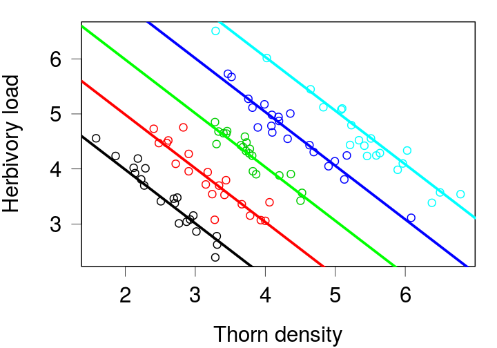

**Simpson's paradox**

### Example: thorns and herbivory

```r
library(lme4)
summary(lmer(y~ x + (1|block)))
```

```
Linear mixed model fit by REML ['lmerMod']
Formula: y ~ x + (1 | block)

REML criterion at convergence: -6

Scaled residuals:
    Min      1Q  Median      3Q     Max
-3.4740 -0.6403  0.0745  0.5321  2.9025

Random effects:
 Groups   Name        Variance Std.Dev.
 block    (Intercept) 2.36630  1.5383
 Residual             0.03789  0.1947
Number of obs: 100, groups:  block, 5

Fixed effects:
            Estimate Std. Error t value
(Intercept)  7.93789    0.70059   11.33
x           -0.97592    0.03393  -28.76

Correlation of Fixed Effects:
  (Intr)
x -0.187
```

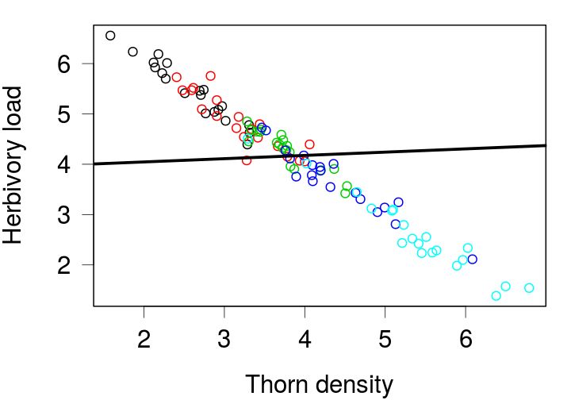

### One more exercise

Look at the simulation code in CodeForOneRepeat2.R

Modify the code to estimate power for the lm() and lmer() in this context

(NB: you can use absolute values of t-values, instead of p-values)

### Conclusion

- Power important and easy to estimate before data collection
- Post-hoc power analysis can **sometimes** rescue an underpowered study
- Simulation approach forces you to understand your stat model
- Unknown variation should be accounted for (mixed models)
- But mixed models are interesting for other reasons…